# Network inference 🌐

Published

March 27, 2025

# 1 Introduction

The `PlnNetwork` model in the pyPLNmodels package is designed for sparse network inference from multivariate count data, using a penalized precision matrix. It allows for network structure learning between variables, such as genes in single-cell RNA sequencing datasets. Moreover, it can induce sparsity on the coefficients of the regression matrix.

This tutorial demonstrates how to:

- Initialize a `PlnNetwork` ([documentation](https://pln-team.github.io/pyPLNmodels/plnnetwork.html)) model from count data or using a formula interface
- Fit the model with regularization on the precision matrix
- Visualize inferred network structures and latent variables
- Gives tools for selecting the optimal penalty
- Induce sparsity on the regression matrix

## 1.1 Statistical background

Compared to the `Pln` model, a constraint is imposed on the precision matrix $\Sigma^{-1}$ of the latent space to enforce sparsity (Chiquet, Robin, and Mariadassou (2019)):

$$\begin{align}
Z_i &\sim \mathcal{N}(X_i^{\top} B, \Sigma), \quad \|\Sigma^{-1}\|_1 \leq C \\
Y_{ij} \mid Z_{ij} &\sim \mathcal{P}(\exp(o_{ij} + Z_{ij})),
\end{align}$$
where $C$ is a penalty parameter. See Chiquet, Robin, and Mariadassou (2019) for more details.

## 1.2 Data importation

For visualization purposes, we use only 20 variables (i.e. genes).

```python
from pyPLNmodels import load_scrna
data = load_scrna(dim = 20)
endog = data["endog"]
```

```
Returning scRNA dataset of size (400, 20)
```

# 2 Model initialization and fitting

A penalty needs to be specified for the model. The greater the penalty, the sparser the precision matrix will be and the lower the number of linked variables. We use a value of $200$ for now.

```python
from pyPLNmodels import PlnNetwork
net = PlnNetwork(endog, penalty=200).fit()
```

```
Setting the offsets to zero.
Fitting a PlnNetwork model with penalty 200 on the precision matrix and lasso  penalty 0 on the regression coefficients.
Intializing parameters ...
Initialization finished.
```

```
Maximum number of iterations (400)  reached in 1.4 seconds.
Last  criterion = 5.4e-06 . Required tolerance = 1e-06
```

# 3 Network visualization

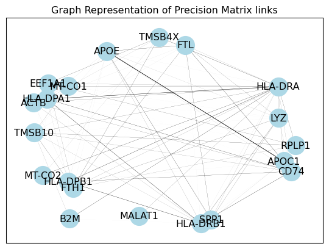

```python
net.viz_network()
```

The network can be accessed as a dictionnary through the `network` attribute:

```python
network = net.network
print(network)
print("Genes associated with APOE: ", network["APOE"])
```

```
{'FTL': ['FTH1', 'SPP1', 'APOE', 'B2M', 'HLA-DRA', 'APOC1', 'TMSB10', 'HLA-DRB1', 'HLA-DPA1', 'HLA-DPB1', 'LYZ'], 'MALAT1': ['APOE', 'HLA-DRA', 'APOC1', 'EEF1A1'], 'FTH1': ['FTL', 'TMSB4X', 'APOE', 'B2M', 'ACTB', 'HLA-DRA', 'APOC1', 'TMSB10', 'EEF1A1', 'HLA-DPA1', 'HLA-DPB1', 'LYZ', 'RPLP1'], 'TMSB4…
Genes associated with APOE:  ['FTL', 'MALAT1', 'FTH1', 'CD74', 'SPP1', 'HLA-DRA', 'APOC1', 'TMSB10', 'EEF1A1', 'HLA-DRB1', 'HLA-DPA1', 'HLA-DPB1', 'LYZ']
```

# 4 Use `PlnNetworkCollection` for selecting the optimal penalty

The penalty is an hyperparameter that needs to be tuned. To explore multiple penalty solutions, use `PlnNetworkCollection`:

```python
from pyPLNmodels import PlnNetworkCollection
collection = PlnNetworkCollection(endog, penalties=[0.1,10,1000]).fit()
```

```
Setting the offsets to zero.
Adjusting 3 PlnNetwork models.

Fitting a PlnNetwork model with penalty 0.1 on the precision matrix and lasso  penalty 0 on the regression coefficients.
Intializing parameters ...
Initialization finished.
```

```
Maximum number of iterations (400)  reached in 0.6 seconds.
Last  criterion = 5.4e-06 . Required tolerance = 1e-06
Fitting a PlnNetwork model with penalty 10 on the precision matrix and lasso  penalty 0 on the regression coefficients.
Intializing parameters ...
Initialization finished.
```

```
Maximum number of iterations (400)  reached in 0.6 seconds.
Last  criterion = 5.4e-06 . Required tolerance = 1e-06
Fitting a PlnNetwork model with penalty 1000 on the precision matrix and lasso  penalty 0 on the regression coefficients.
Intializing parameters ...
Initialization finished.
```

```
Maximum number of iterations (400)  reached in 0.6 seconds.
Last  criterion = 5.4e-06 . Required tolerance = 1e-06
======================================================================

DONE!
Best model (lower BIC): penalty 0.1
    Best model(lower AIC): penalty  0.1

======================================================================
```

## 4.1 Evaluate model quality

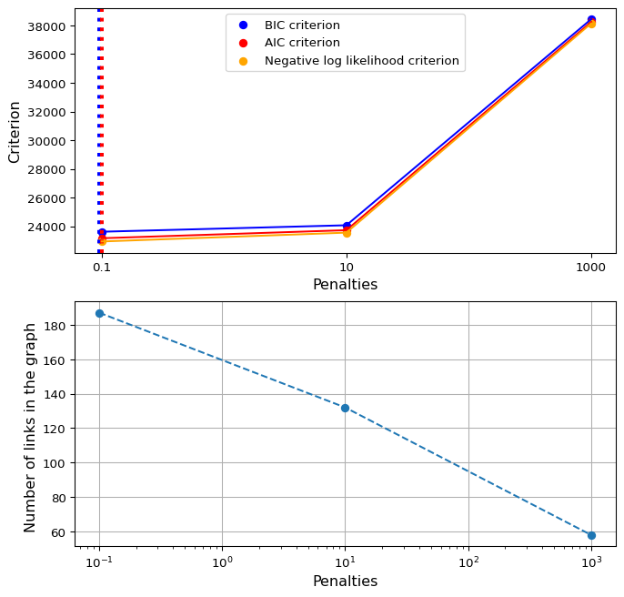

```python
collection.show(figsize=(8, 8))
```

This displays the BIC, AIC and log-likelihood criteria for each model, helping to identify the most suitable one. Additionally, the number of links (i.e., non-zero elements in the precision matrix) is provided. You may consider using the ELBOW method to select the optimal model based on the number of links.

## 4.2 Selecting the best model

The best model can be chosen according to the BIC or AIC:

```python
best_net = collection.best_model("BIC") # Could be also AIC.
print(best_net)
```

```
A multivariate PlnNetwork with penalty 0.1 on the precision matrix and lasso  penalty 0 on the regression coefficients.
======================================================================
     Loglike   Dimension    Nb param         BIC         AIC         ICL    Nb edges
   -22940.33          20         227  23620.3633   23167.332    10461.07         187

======================================================================
* Useful attributes
    .latent_variables .latent_positions .coef .covariance .precision .model_parameters .latent_parameters .optim_details
* Useful methods
    .transform() .show() .predict() .sigma() .projected_latent_variables() .plot_correlation_circle() .biplot() .viz() .pca_pairplot() .plot_expected_vs_true()
* Additional attributes for PlnNetwork are:
    .network .nb_zeros_precision
* Additional methods for PlnNetwork are:
    .viz_network()
```

One can also access each individual model in the collection, using the penalty as a key:

```python
print(collection[10])
```

```
A multivariate PlnNetwork with penalty 10 on the precision matrix and lasso  penalty 0 on the regression coefficients.
======================================================================
     Loglike   Dimension    Nb param         BIC         AIC         ICL    Nb edges
   -23557.72          20         172  24072.9867  23729.7207    10589.69         132

======================================================================
* Useful attributes
    .latent_variables .latent_positions .coef .covariance .precision .model_parameters .latent_parameters .optim_details
* Useful methods
    .transform() .show() .predict() .sigma() .projected_latent_variables() .plot_correlation_circle() .biplot() .viz() .pca_pairplot() .plot_expected_vs_true()
* Additional attributes for PlnNetwork are:
    .network .nb_zeros_precision
* Additional methods for PlnNetwork are:
    .viz_network()
```

and loop through the collection:

```python
for net in collection.values():
    print(net)
```

[output not shown]

## 4.3 Inducing sparsity on the regression matrix

By default, `PlnNetwork` does not impose any sparsity on the regression matrix. To induce sparsity, set the `penalty_coef` parameter to a positive float when initializing the model:

```
Setting the offsets to zero.
Fitting a PlnNetwork model with penalty 200 on the precision matrix and lasso  penalty 20 on the regression coefficients.
Intializing parameters ...
Initialization finished.
```

```
Maximum number of iterations (400)  reached in 0.6 seconds.
Last  criterion = 5.4e-06 . Required tolerance = 1e-06
```

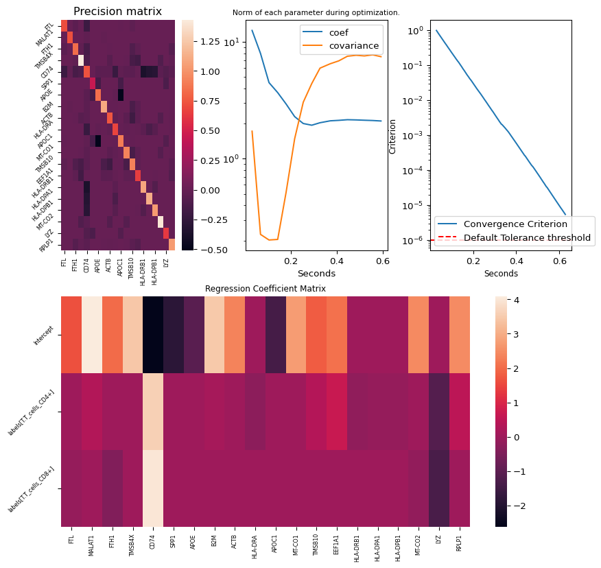

```python
net = PlnNetwork.from_formula("endog ~ 1 + labels", data = data,  penalty_coef=20, penalty=200).fit()
net.show()
```

The default sparsity is the `lasso` penalty, but you can also use the `group_lasso` and `sparse_group_lasso` penalties. This can be done by specifying the `penalty_coef_type` parameter when initializing the model:

```
Setting the offsets to zero.
Fitting a PlnNetwork model with penalty 200 on the precision matrix and group_lasso  penalty 50 on the regression coefficients.
Intializing parameters ...
Initialization finished.
```

```
Maximum number of iterations (400)  reached in 0.6 seconds.
Last  criterion = 5.39e-06 . Required tolerance = 1e-06
```

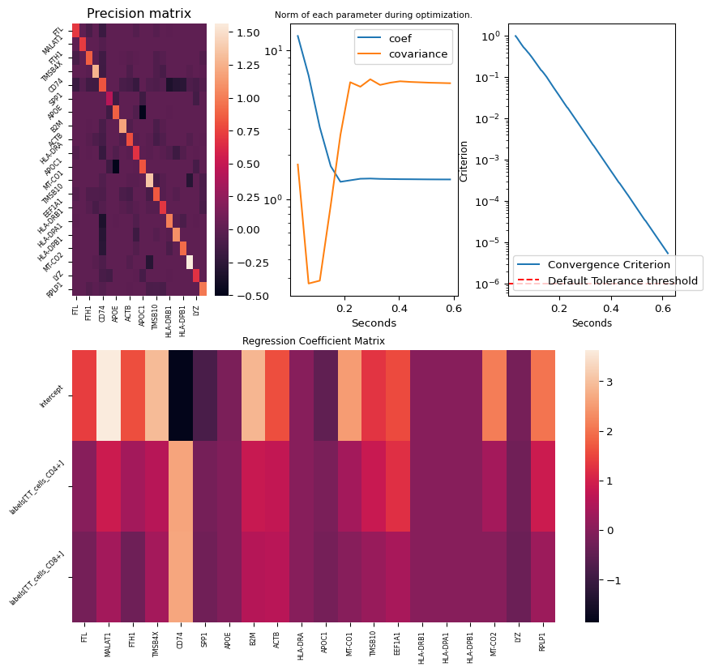

```python
net = PlnNetwork.from_formula("endog ~ 1 + labels", data = data, penalty_coef_type="group_lasso",  penalty_coef=50, penalty=200).fit()
net.show()
```

The coefficients of the regression matrix are therefore sparse.

## References

Batardière, Bastien, Joon Kwon, and Julien Chiquet. 2024. “pyPLNmodels: A Python Package to Analyze Multivariate High-Dimensional Count Data.” *Journal of Open Source Software*.

Chiquet, Julien, Stephane Robin, and Mahendra Mariadassou. 2019. “Variational Inference for Sparse Network Reconstruction from Count Data.” In *Proceedings of the 36th International Conference on Machine Learning*, 97:1162–71. Proceedings of Machine Learning Research. PMLR.